# Data Challenge 1: Daily Cow Visualizations

Ziwen Zhang

2022-09-27

### load in the required libraries

```r
library(readr)
library(tidyverse)
library(here)
```

### read in the data

```r
state_milk_production <- read.csv("D:/Cornell/Data_Science_I/DataChallenges/A1/data/state_milk_production.csv")
clean_cheese <- read.csv("D:/Cornell/Data_Science_I/DataChallenges/A1/data/clean_cheese.csv")
fluid_milk_sales <- read.csv("D:/Cornell/Data_Science_I/DataChallenges/A1/data/fluid_milk_sales.csv")
milk_products_facts <- read.csv("D:/Cornell/Data_Science_I/DataChallenges/A1/data/milk_products_facts.csv")
milkcow_facts <- read.csv("D:/Cornell/Data_Science_I/DataChallenges/A1/data/milkcow_facts.csv")
```

### disable scientific notation

```r
options(scipen = 999)
```

## Figure 1

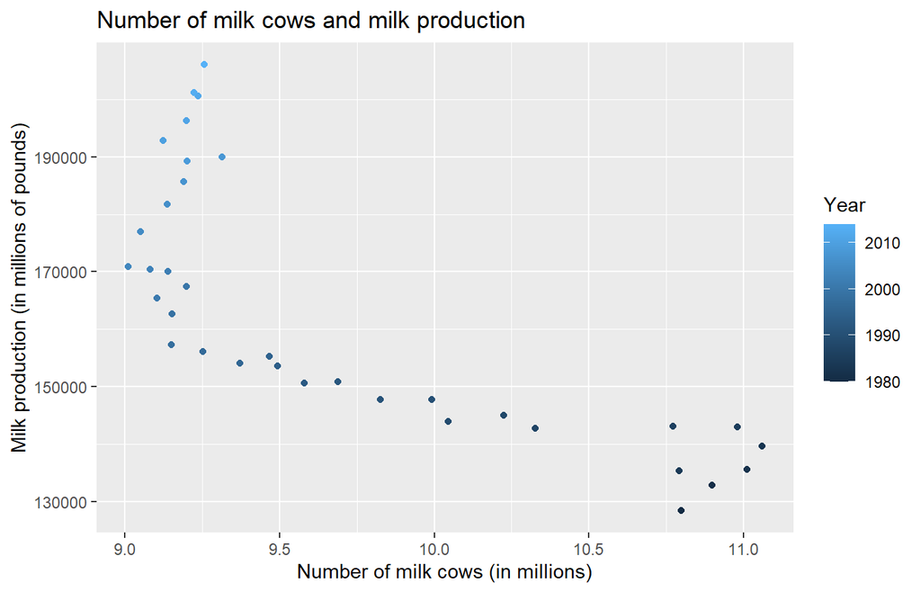

```r
## make a scatter plot to show the relationship between milk production and number of milk cows
ggplot(data = milkcow_facts, ## initialize ggplot object
            aes(y = milk_production_lbs / 1000000,
                x = avg_milk_cow_number / 1000000)) + ## scale to millions
  geom_point(aes(color = year)) + ## color the point by year
  labs(y = 'Milk production (in millions of pounds)',
       x = 'Number of milk cows (in millions)', ## label x and y axis
       title = 'Number of milk cows and milk production', ## add title
       color = "Year") ## relabel the legend
```

This scatter plot shows the relationships between number of milk cows and milk production over time. In early years, the milk production is low even if the number of milk cows is large. With time passes, milk production became higher and the number of cows became smaller. After late 1990s, the number of milk cows became relatively stable whereas the milk production significantly increased, indicating an improved of milk production efficiency.